# MA132 Enrollment Spring 2024 Prediction

2023-10-02

First, we will load our libraries.

```r
library(here)
library(janitor)
library(tidyverse)
library(skimr)
```

Next, we will read the csv file with the data from enrollment in past semesters.

```r
thisfile = here("data_raw", "CU_ACAD_DEPT_WHEN_OFF_ENRL.csv")
df1 = read_csv(thisfile) %>% clean_names()
```

Now, we will skim the data to see how many columns there are.

```r
skimr::skim(df1)
```

```
── Data Summary ────────────────────────
                           Values
Name                       df1
Number of rows             4585
Number of columns          12
_______________________
Column type frequency:
  character                8
  numeric                  4
________________________
Group variables            None
```

|  | skim_variable | n_missing | complete_rate | min | max | empty | n_unique | whitespace |
| --- | --- | --- | --- | --- | --- | --- | --- | --- |
| 1 | current_status | 0 | 1.0000000 | 6 | 8 | 0 | 2 | 0 |
| 2 | course_id | 0 | 1.0000000 | 6 | 6 | 0 | 94 | 0 |
| 3 | subject | 0 | 1.0000000 | 2 | 4 | 0 | 4 | 0 |
| 4 | section | 0 | 1.0000000 | 1 | 4 | 0 | 91 | 0 |
| 5 | term_8 | 0 | 1.0000000 | 9 | 11 | 0 | 30 | 0 |
| 6 | title | 0 | 1.0000000 | 10 | 30 | 0 | 87 | 0 |
| 7 | component | 0 | 1.0000000 | 3 | 3 | 0 | 7 | 0 |
| 8 | instructor | 19 | 0.9958561 | 6 | 50 | 0 | 329 | 0 |

|  | skim_variable | n_missing | complete_rate | mean | sd | p0 | p25 | p50 | p75 | p100 | hist |
| --- | --- | --- | --- | --- | --- | --- | --- | --- | --- | --- | --- |
| 1 | acad_org | 0 | 1 | 16300.00000 | 0.00000 | 16300 | 16300 | 16300 | 16300 | 16300 | ▁▁▇▁▁ |
| 2 | catalog | 0 | 1 | 291.91276 | 215.52427 | 30 | 132 | 231 | 381 | 810 | ▇▆▂▁▂ |
| 3 | term_7 | 0 | 1 | 4192.92497 | 28.21579 | 4146 | 4169 | 4192 | 4219 | 4242 | ▇▇▇▇▆ |
| 4 | tot_enrl | 0 | 1 | 20.71494 | 21.79861 | 0 | 5 | 17 | 26 | 137 | ▇▁▁▁▁ |

Next, we create another data frame that takes df1 and only shows the data from the classes we want to look at.

```r
df_calc = df1 |>
  select(-acad_org, -title, -current_status, -course_id) |>
  filter(subject == "MA",
         catalog %in% c(131, 132),
         component == "LEC")
```

Now, we create another dataframe, df2, which will further filter df_calc.

```r
df2 = df_calc %>%
  slice_head(n = 1, by = c(term_7, catalog, section)) %>%
  select(-subject, -component, -instructor) %>%
  mutate(catalog = as.character(catalog)) %>%
  separate_wider_delim(term_8, delim = " ", names = c("semester", "year")) %>%
  mutate(ay = ((term_7 - 4000) / 10 ) %>% round()) %>%
  filter(!(catalog == "131" & semester == "Spring")) %>%
  filter(semester %in% c("Fall", "Spring")) %>%
  summarise(tot_enrl = sum(tot_enrl), .by = c(catalog, semester, ay)) %>%
  pivot_wider(values_from = tot_enrl,
              id_cols = ay,
              names_from = c("catalog", "semester"),
              names_prefix = "ma") %>%
  clean_names()
```

Now, we will visualize df2.

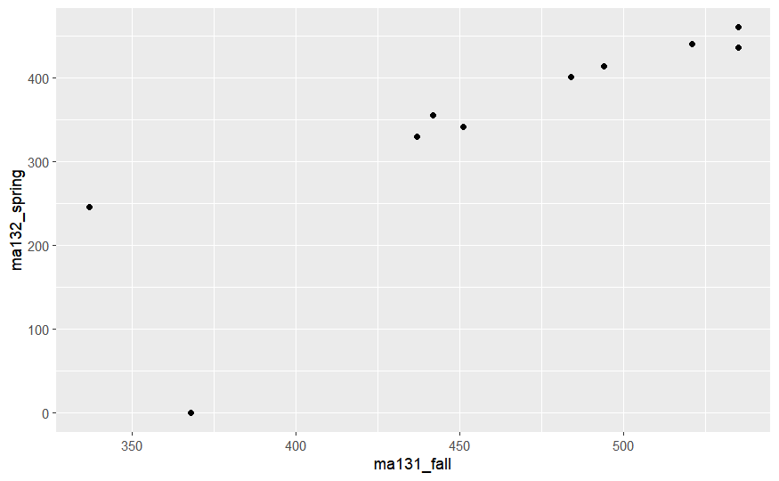

```r
df2 %>%
  ggplot(aes(ma131_fall, ma132_spring)) +
  geom_point()
```

Note: We can see from the graph, enrollment for ma131_fall increases as ma132_increases enrollment increases. In order for us to assume that most people move onto ma132 in the spring after taking ma131 in the fall, we should also look at results of ma132 in the fall of that same ma131_fall semester.

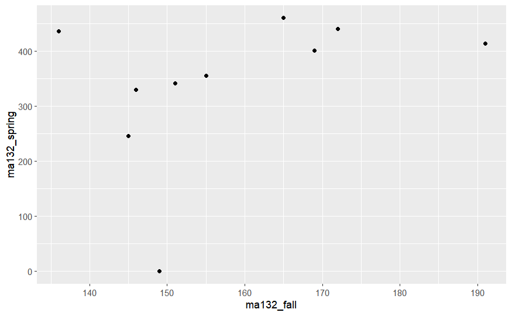

```r
df2 %>%
  ggplot(aes(ma132_fall, ma132_spring)) +
  geom_point()
```